# Linealidad de los betas

Hernan montes

2023-10-05

## 6.5 Complemento: Una pequeña explicación sobre la linealidad de los betas

En esta sección vamos a aclarar el asunto de que los BETAS sean lineales. La linealidad en este contexto hace referencia a que no tengan potencias y que los **coeficientes sean independendientes entre ellos**.

Supongamos un modelo con coeficientes repetidos.

$$E(y|x) = \beta_0 + \alpha * x + \alpha *
x^2$$
Debemos factorizarlos para evitar estimarlos por separado y producir inconsistencias,esto debido a que ambos alpha (coeficientes) son dependientes. Es decir, reescribimos:

$$E(y|x) = \beta_0 + \alpha (x + x^2)$$
Donde el componente x + x² será el vector de valores de la variable predictora, que puede pensarse como una variable nueva:

$$\tilde{x} = x + x^2$$
Y por lo tanto pensar al modelo como:

$$E(y|x) = \beta_0 + \alpha *
\tilde{x}$$

Esta transformación garantiza la creación de un nuevo modelo lineal respecto a $\beta_0$ y $\alpha$.

Es importante anotar que el dataframe que alimentará el modelo deberá tener computada la variable auxiliar $\tilde{x}$, la cual debe ser pasada a la función encargada de estimar parámetros.

Esto corresponde a crear una nueva variable con los cálculos mencionados $\tilde{x} = x + x^2$. Sin embargo, para graficar es conveniente usar la variable original.

```r
# Se define una semilla para generar los aleatorios.
set.seed(77)

x <- seq(1:10)
alpha <- 0.7
b0 <- 0.2

E_y_x_3 = b0 + alpha * (x + x^2)
y_obs_3 = E_y_x_3 + rnorm(10, 0, 4)

x_auxiliar = x + x^2

datos_simulados_2 <- data.frame(
  x = x,
  x_2 = x^2,
  x_auxiliar = x_auxiliar,
  E_y_x_3 = E_y_x_3,
  y_obs_3 =  y_obs_3,
  y_pred_3_1 = predict(lm(y_obs_3 ~ poly(x, 2))),
  y_pred_3_2 = predict(lm(y_obs_3 ~ x_auxiliar )))


modelo1a <- lm(y_obs_3 ~ poly(x, 2))
modelo1b <- lm(y_obs_3 ~ poly(x, 2, raw = TRUE))
modelo2 <- lm(y_obs_3 ~ x_auxiliar )
```

Nótese que los coeficientes arrojados por el modelo 1a al invocar la función poly sin parámetro de raw=TRUE, no son atribuibles o no están asociados a los términos $1,x,x^2$, es decir, **No es válido escribir**:

$E(y|x)=$ 32.61 * 1 + 76.82 * x + 16.74 * x^2

Esta ecuación no sería válida porque al remplazar para $x=5$ se obtiene $E(y|5)=$ 835.11, mientras que al remplazar en el modelo con el parámetro raw = TRUE, se obtendría: $E(y|5)=$ 22.55

Esto se debe a que los coeficientes anclados al modelo_1a están diseñados para ser usados sobre la siguiente base de polinomios ortogonales:

- $P_1(x)= a$
- $P_2(x)=m*x - c$
- $P_3(x)= k_1 + k_2 *x + k_3 * x ^2$

Donde $a,m,c,k_1,k_2,k_3$ son parámetros estimados que lamentablemente no están siendo arrojados por el modelo.

A continuación se muestra el resumen de cada uno de los modelos, utilizando la función summary().

```r
summary(modelo1a)
```

```
##
## Call:
## lm(formula = y_obs_3 ~ poly(x, 2))
##
## Residuals:
##     Min      1Q  Median      3Q     Max
## -5.4051 -2.0000  0.2405  2.8394  3.5594
##
## Coefficients:
##             Estimate Std. Error t value Pr(>|t|)
## (Intercept)   32.607      1.143  28.533 1.67e-08 ***
## poly(x, 2)1   76.820      3.614  21.257 1.28e-07 ***
## poly(x, 2)2   16.736      3.614   4.631  0.00239 **
## ---
## Signif. codes:  0 '***' 0.001 '**' 0.01 '*' 0.05 '.' 0.1 ' ' 1
##
## Residual standard error: 3.614 on 7 degrees of freedom
## Multiple R-squared:  0.9854, Adjusted R-squared:  0.9813
## F-statistic: 236.7 on 2 and 7 DF,  p-value: 3.736e-07
```

```r
summary(modelo1b)
```

```
##
## Call:
## lm(formula = y_obs_3 ~ poly(x, 2, raw = TRUE))
##
## Residuals:
##     Min      1Q  Median      3Q     Max
## -5.4051 -2.0000  0.2405  2.8394  3.5594
##
## Coefficients:
##                         Estimate Std. Error t value Pr(>|t|)
## (Intercept)               2.1133     4.2503   0.497  0.63427
## poly(x, 2, raw = TRUE)1   0.4458     1.7751   0.251  0.80890
## poly(x, 2, raw = TRUE)2   0.7283     0.1573   4.631  0.00239 **
## ---
## Signif. codes:  0 '***' 0.001 '**' 0.01 '*' 0.05 '.' 0.1 ' ' 1
##
## Residual standard error: 3.614 on 7 degrees of freedom
## Multiple R-squared:  0.9854, Adjusted R-squared:  0.9813
## F-statistic: 236.7 on 2 and 7 DF,  p-value: 3.736e-07
```

```r
summary(modelo2)
```

```
##
## Call:
## lm(formula = y_obs_3 ~ x_auxiliar)
##
## Residuals:
##     Min      1Q  Median      3Q     Max
## -5.5584 -2.0443  0.1458  2.8929  3.7758
##
## Coefficients:
##             Estimate Std. Error t value Pr(>|t|)
## (Intercept)  1.55135    1.71306   0.906    0.392
## x_auxiliar   0.70580    0.03039  23.222 1.26e-08 ***
## ---
## Signif. codes:  0 '***' 0.001 '**' 0.01 '*' 0.05 '.' 0.1 ' ' 1
##
## Residual standard error: 3.386 on 8 degrees of freedom
## Multiple R-squared:  0.9854, Adjusted R-squared:  0.9836
## F-statistic: 539.3 on 1 and 8 DF,  p-value: 1.256e-08
```

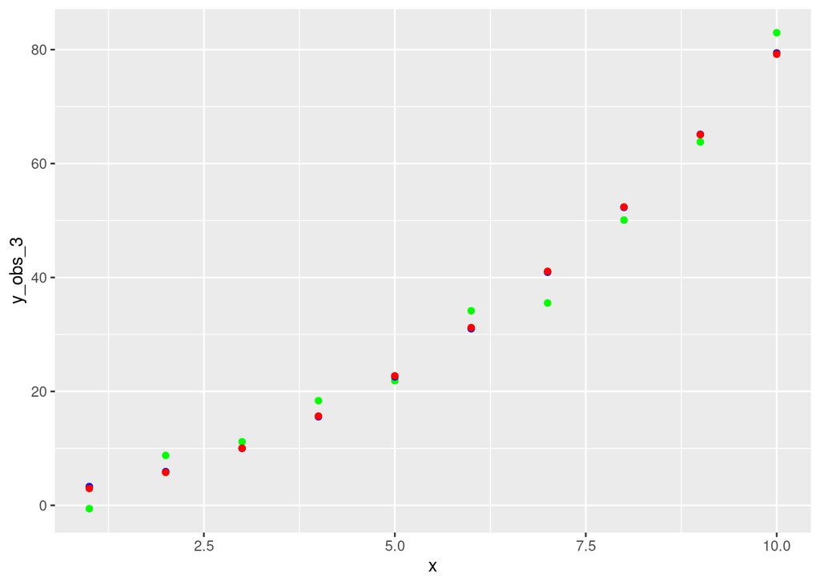

```r
datos_simulados_2 %>%
  ggplot(aes(x = x , y = y_obs_3))+
  geom_point(col = 'green')+
  geom_point(aes(y = y_pred_3_1), col = 'blue')+
  geom_point(aes(y = y_pred_3_2), col = 'red')
```

```r
# TAREA,
# Buscar la descomposición ortogonal de los vectores.

u1 = 1/sqrt(2)
u2 = sqrt(3/2) * (5-1)
u3 = sqrt(5/2) * ((3/2)*(5^2) - 3*5 + 1)

#E_y_5 = coef1 * u1 + coef2*u2 + coef3*u3
E_y_5 = modelo1a$coefficients[1] * u1 + modelo1a$coefficients[2]*u2 + modelo1a$coefficients[3]*u3

modelo1a$coefficients[1]
```

```
## (Intercept)
##    32.60656
```

```r
modelo1a$coefficients[2]
```

```
## poly(x, 2)1
##     76.8198
```

```r
modelo1a$coefficients[3]
```

```
## poly(x, 2)2
##    16.73598
```

```r
E_y_5
```

```
## (Intercept)
##     1021.25
```